# Introduction to R and Rstudio

Session - import csv

Zoë Turner

## Getting data into to R

There are packages to import all types of data and RStudio has wizards for just a few of the possibilities.

We are going to first import a csv using the wizard but also get the code to copy to scripts for reproducibility.

## Import wizard

We will use the “Import Dataset” button (but you can also click on the file itself):

[figure not shown]

## Two ways of importing csv

The base R doesn’t use any packages but imports a `data frame` in R whereas {readr} is built on the base R and creates a neater `tibble`

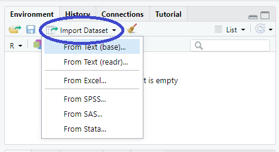

## tibble = data frame

`tibble` is synonymous with `data frame` but acts differently

> A tibble… is a modern reimagining of the data.frame…

> Tibbles are data.frames that are **lazy and surly**: they do less (i.e. they don’t change variable names or types, and don’t do partial matching) and **complain more** (e.g. when a variable does not exist).

> This forces you to confront problems earlier, typically leading to cleaner, more expressive code.

https://tibble.tidyverse.org/)

## Find the file

Locate the file `capacity_ae.csv`

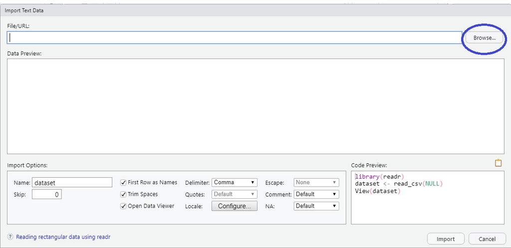

## Data preview

When the file is located {readr} is used automatically and the data preview populates

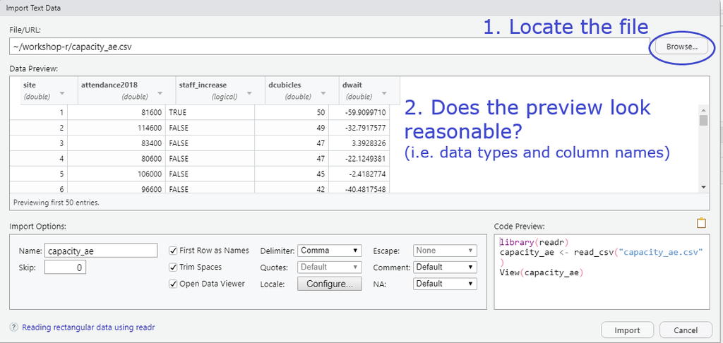

## Getting the code for later

Whilst it’s possible just to select import, RStudio gives you the option to copy the code:

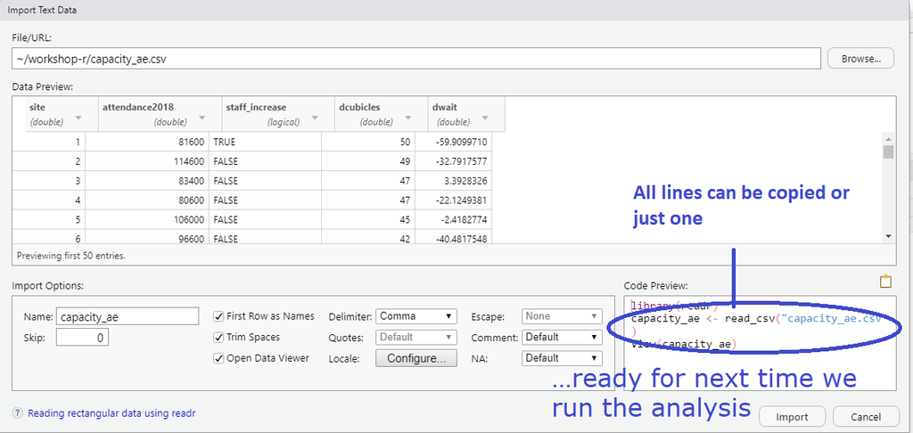

# Running the code

In the editor, once copied from the wizard or shared in a script:

```r
library(readr) # Good practice to put this at the top of a script

capacity_ae <- read_csv("capacity_ae.csv")
```